# Fast Many-Facet Measurement and Scoring with mfrmr

## Overview

`mfrmr` provides high-speed C++ estimation, person scoring, diagnostics, `RajuSA-Welch` pairwise bias / DFF screening, color-vision-safe `ggplot2` visualizations, generalizability analysis, and APA-style and rater-feedback reports. Start with `mfrm_analysis()` to run these analyses together, or use `mfrm_workflow()` and the `step_mfrm_*()` functions to review each stage.

The **Generalized Many-Facet Rasch Model (GMFRM)** estimates discrimination for one or two facets. The name follows [Uto and Ueno (2020, Section 6)](https://doi.org/10.1007/s41237-020-00115-7), who generalized the many-facet Rasch model, which holds discrimination constant. In `mfrmr`, GMFRM covers an adjacent-category many-facet GPCM with facet-specific steps and a rating-scale form (many-facet RS-GPCM) with common steps. Use `model = "GPCM"` for either form, with `step_facet = "Common"` for shared steps on a common rubric. See `?fit_mfrm` for supported specifications.

## From ratings to a report

Each row of the bundled data is one rater’s score for one person on one rubric criterion. Check `glance()` for linkage and inference status before interpreting estimates. The Wright map places examinee ability, rater severity, and criterion difficulty on a common logit scale. The report also documents rater fit, observed and expected agreement, separation, observed-score G-Study and D-Study, and estimation notes. The report identifies results that cannot be interpreted with the fitted model or design.

```r
library(mfrmr)
ratings <- load_mfrmr_data("example_core")
wf <- mfrm_analysis(ratings, "Person", c("Rater", "Criterion"), "Score")
glance(wf)[c("n_obs", "connected", "converged", "inference_status")]
```

```
#> # A tibble: 1 × 4
#>   n_obs connected converged inference_status
#>   <int> <lgl>     <lgl>     <chr>
#> 1   768 TRUE      TRUE      ready
```

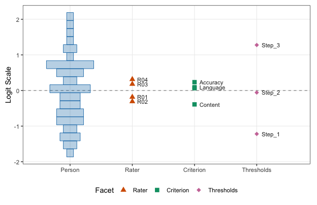

```r
plot(wf, type = "wright")
```

```r
plan <- data.frame(Rater = c("R01", "R02"),
                   Criterion = c("Content", "Organization"))
report_file <- render_mfrm_report(
  wf, file = tempfile(fileext = ".html"), format = "html", reference_plan = plan
)
feedback <- render_mfrm_report(wf, rater = "R01")
```

Use `?mfrm_analysis` for input options and `?render_mfrm_report` for Markdown, HTML, and Word output. For a guide to the corresponding FACETS output and when to use each model, see the [assessment walkthrough](https://github.com/Ryuya-dot-com/mfrmr/blob/v0.3.2/vignettes/articles/mfrmr-assessment.Rmd).

## 1. Connectivity Audit and Fast C++ Estimation (RSM, PCM, and GMFRM)

Each row of `example_core` represents one person’s rating by a rater on an analytic rubric criterion (`Score` 1 to 4):

```r
head(ratings, 4)
```

```
#>         Study Person Rater Criterion Score Group
#> 1 ExampleCore   P001   R01   Content     3     A
#> 2 ExampleCore   P002   R01   Content     3     A
#> 3 ExampleCore   P003   R01   Content     4     A
#> 4 ExampleCore   P004   R01   Content     3     A
```

```r
conn <- check_mfrm_connectivity(
  ratings,
  person = "Person",
  facets = c("Rater", "Criterion"),
  score = "Score"
)
conn$connected
```

```
#> [1] TRUE
```

```r
conn$n_subsets
```

```
#> [1] 1
```

An assessment team may ask whether the same category steps work for every criterion, and whether allowing different discrimination changes the fit. The RSM shares steps across criteria; the PCM gives each criterion its own steps; the GMFRM additionally estimates criterion discrimination. Fit all three by marginal maximum likelihood (`MML`) to the same ratings, with the same fixed standard-normal ability distribution and 31-point integration rule. These common settings make their nested likelihood comparisons interpretable. `person_score = "WLE"` chooses Warm’s score for reporting persons; it does not change the MML calibration likelihood.

```r
fit_rsm <- fit_mfrm(
  ratings,
  person = "Person",
  facets = c("Rater", "Criterion"),
  score = "Score",
  model = "RSM",
  method = "MML",
  person_score = "WLE"
)
print(fit_rsm)
```

```
#> Many-Facet Measurement Fit [MML / RSM | Score: WLE]
#>   Ratings: 768 | Persons: 48 | Free par: 8 | Connected: YES (1 subset)
#>   Converged: TRUE (17 iter, max|grad| = 2.51e-14, 0.0680 s) | LogLik = -900.0126 | AIC = 1816.03
#>   Inference: ready
#>   Population SD = 1.0000 | EAP Reliability = 0.8979
```

```r
fit_rsm$facets[, c("Facet", "Level", "Estimate", "ModelSE", "RealSE", "FairM", "InfitMnSq")]
```

```
#>       Facet        Level    Estimate    ModelSE     RealSE    FairM InfitMnSq
#> 1     Rater          R01 -0.18381535 0.08209146 0.08209146 2.638184 0.9979413
#> 2     Rater          R02 -0.30884784 0.08298771 0.08298771 2.723503 0.8746011
#> 3     Rater          R03  0.17950280 0.08202273 0.08202273 2.386007 0.9171260
#> 4     Rater          R04  0.31316039 0.08294736 0.08294736 2.293516 0.9857476
#> 5 Criterion     Accuracy  0.23363891 0.08237044 0.08237044 2.348443 0.9671730
#> 6 Criterion      Content -0.38997316 0.08384145 0.08384145 2.778056 0.9570214
#> 7 Criterion     Language  0.09146369 0.08172648 0.08295481 2.447263 1.0302852
#> 8 Criterion Organization  0.06487056 0.08167028 0.08167028 2.465782 0.8216215
```

```r
fit_pcm <- fit_mfrm(
  ratings,
  person = "Person",
  facets = c("Rater", "Criterion"),
  score = "Score",
  model = "PCM",
  step_facet = "Criterion",
  method = "MML"
)

fit_gpcm <- fit_mfrm(
  ratings,
  person = "Person",
  facets = c("Rater", "Criterion"),
  score = "Score",
  model = "GPCM",
  step_facet = "Criterion",
  slope_facet = "Criterion",
  spec = list(gpcm_mml_identification = "fixed_standard_normal"),
  control = list(quad_points = 31L)
)
fit_gpcm$slopes[, c("Facet", "Level", "Estimate", "ModelSE")]
```

```
#>       Facet        Level  Estimate   ModelSE
#> 1 Criterion     Accuracy 0.9152991 0.1202736
#> 2 Criterion      Content 0.9227647 0.1274870
#> 3 Criterion     Language 1.0659041 0.1463813
#> 4 Criterion Organization 1.1107795 0.1448946
```

```r
comparison <- anova(fit_rsm, fit_pcm, fit_gpcm)
comparison$lrt
```

```
#>   Simpler  Complex FreeParamsSimpler FreeParamsComplex df    ChiSq     pValue
#> 1 fit_rsm  fit_pcm                 8                14  6 13.52681 0.03539257
#> 2 fit_pcm fit_gpcm                14                17  3  1.24064 0.74327460
```

Read each likelihood-ratio test as evidence about the restrictions removed between two models. A small p-value supports relaxing those restrictions under the likelihood assumptions; it does not establish practical importance or validate the more complex model. Inspect parameter estimates, uncertainty and residual diagnostics before choosing a model. Ineligible comparisons return no LRT table and explain the reason in `comparison$comparison_basis`.

In this example, the RSM-to-PCM p-value is 0.0354, whereas the PCM-to-GMFRM p-value is 0.743. At an illustrative 5% threshold, the data support criterion-specific steps, with little evidence here for the additional discrimination parameters. This is a model-comparison result for these ratings, not a recommendation to use PCM for every rubric.

Check `summary(fit_rsm)$readiness` before interpreting intervals. Optimizer convergence means that its stopping rule was met. Readiness additionally checks the implemented connectivity, information-matrix and boundary conditions; it does not establish model fit or nominal finite-sample coverage. Sparse ratings, rare categories and dependence among ratings can still affect uncertainty.

Use standard S3 methods for a supported prediction scenario and calibration intervals:

```r
predict(
  fit_rsm,
  newdata = data.frame(theta = c(-1, 0, 1), Rater = "R01", Criterion = "Content"),
  type = "response"
)
```

```
#> [1] 2.216411 2.898806 3.440895
```

```r
confint(fit_rsm, component = "facets")
```

```
#>                               2.5%       97.5%
#> Rater:R01              -0.34471166 -0.02291904
#> Rater:R02              -0.47150075 -0.14619492
#> Rater:R03               0.01874120  0.34026440
#> Rater:R04               0.15058654  0.47573423
#> Criterion:Accuracy      0.07219580  0.39508201
#> Criterion:Content      -0.55429938 -0.22564693
#> Criterion:Language     -0.06871728  0.25164465
#> Criterion:Organization -0.09520024  0.22494137
```

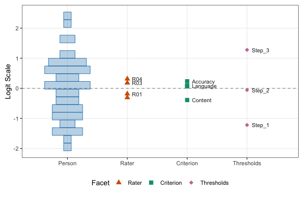

```r
plot(fit_rsm, type = "wright", palette = "okabe_ito")
```

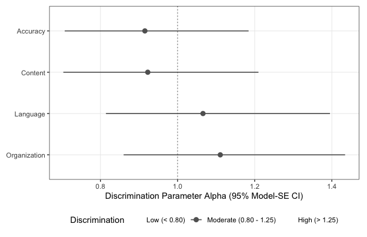

```r
plot(fit_gpcm, type = "slopes", palette = "monochrome")
```

Positive rater estimates indicate greater severity, and positive criterion estimates indicate greater difficulty on the model’s logit scale. The facet intervals describe calibration uncertainty. Predictions above condition on the specified ability and calibrated facet levels; they are not prediction intervals for a new person’s observed score. See `?fit_mfrm` and `?confint.mfrm_fit` for identification, supported interval types and their limitations.

## 2. High-Speed Batch Replications

`mfrm_batch_fit()` executes Monte Carlo or bootstrap replications inside C++ worker threads without R interpreter overhead:

```r
set.seed(42)
rep_scores <- replicate(5L, sample(1:4, nrow(ratings), replace = TRUE))
batch_summary <- mfrm_batch_fit(
  ratings,
  person = "Person",
  facets = c("Rater", "Criterion"),
  score = "Score",
  score_matrix = rep_scores,
  method = "CML",
  model = "RSM",
  rating_min = 1,
  rating_max = 4,
  threads = 1L,
  return_fits = FALSE
)
batch_summary
```

```
#>   Replicate Converged Iterations    LogLik   MaxAbsGrad
#> 1         1      TRUE          5 -923.7045 1.048051e-13
#> 2         2      TRUE          5 -926.1138 1.264544e-13
#> 3         3      TRUE          5 -924.4776 4.959460e-14
#> 4         4      TRUE          5 -926.0465 7.460699e-14
#> 5         5      TRUE          5 -919.2218 4.263256e-14
```